# $\color{purple}{\text{FOMC Statements (2007-2022):}}$

## $\color{purple}{\text{Reading Between the Lines}}$

[figure not shown]

**Alexander Ng & Philip Tanofsky** **Data 620 - Web Analytics**

**May 22, 2022**

## $\color{blue}{\text{Executive Summary}}$

The Federal Open Market Committee (FOMC) produces policy statements that are closely analyzed by financial markets, politicians and business leaders.

- We analyze a corpus of 126 FOMC statements from Jan 2007-May 2022 using natural language processing methods and
- compare the statements to financial market variables, economic indicators and known policy initiatives of the Federal Reserve.

Using Latent Dirichlet Allocation (LDA), our findings are:

- $N=5$ topics suffices to model the FOMC statements
- topic weights vary like step functions with either 0% or 100% weights
- a strong temporal link between topic inception and the four programs of quantitative easing (QE)
- other standard LDA plots are unhelpful in discovering the latent variable: QE regimes.

Using sentiment analysis, our findings are:

- A comparison of 4 methods to extract sentiment of the FOMC statements finds the Loughran-McDonald polarity measure to perform best, coinciding with the 2008, 2020 recession.
- We regress sentiment changes to financial asset returns and macroeconomic variable changes over longer time horizons and find no statistical significant effect - a result consistent with market efficiency.
- The sign of the regression coefficients of the change in macroeconomic indicators versus subsequent sentiment changes are consistent with our expectations.

## $\color{blue}{\text{1 - Introduction}}$

- 1 - Prior Research
- 2 - Exploratory Data Analysis and Wrangling
- 3 - LDA Model Topics correspond to QE Waves
- 4 - FOMC Sentiment Analysis
- 5 - Discussion

The Federal Open Market Committee (FOMC) is the key decision making body at the US Federal Reserve. It sets the target Federal Funds interest rate, sets monetary policy to meet its dual mandate on managing inflation to a moderate and stable target of 2 percent and maximum employment consistent with the inflation target. The FOMC statement is released every 6-8 weeks and announces the new target interest rate, views of current and future economic conditions and provides an outlook for future rates and asset purchases. FOMC statements affect financial markets and business investment decisions.

A great deal of academic research has investigated the FOMC statements, minutes, transcripts. Machine learning and time series studies have been applied to FOMC corpora as well. Sentiment analysis and study of FOMC communications impact on markets and economics have been extensive. The related work cited below is just a sample. Rosa (2013) finds that FOMC statements move asset prices by increasing volatility of 10 year Treasury yields, SP500 Index returns, Euro-USD, Swiss Franc-USD, Japanese Yen-USD FX rates within 5 minutes of the statements release. Lucca and Trebbi (2009) find that the hawkish or dovish tone of the FOMC statements can influence longer maturity Treasury rates. Gu, Kurov, Wolfe (2018) find a 49 basis point increase in U.S. stock prices within the first hour after recent FOMC announcements. Cieslak, Morse, Vissing-Jorgensen (2019) shows much of the U.S. equity premium since 1994 has been earned on even numbered weeks tied to the FOMC meeting cycle. They propose a causal explanation in terms of informal communications from the Fed. Sentiment analysis using the positive and negative tone of the FOMC minutes using the financially oriented Loughran-McDonald dictionary has been demonstrated by Cannon (2015) to have significant correlation to real economic indicators. Cannon showed a 26% positive correlation between the sentiment of Fed members to the Chicago Fed National Activity Index (CFNAI).

## $\color{blue}{\text{2 - Preliminaries and Exploratory Data Analysis}}$

This section prepares the datasets and explores the some trends of the FOMC statements and their related macroeconomic and financial timeseries from the 2007-2022 period.

- FOMC Corpus
- FRED Time Series
- Time Dynamics - Leads and Lags
- Visualizating the Data

### $\color{green}{\text{2.1 - FOMC Corpus}}$

In this section, we describe the data preparation steps to obtain the FOMC statement corpus.

Each statement is individually retrieved from the Federal Reserve website (www.federalreserve.gov) based on the date of the Fed meeting. The list of URLs was manually reviewed and confirmed as accurate. Using an API request to the site and the `BeautifulSoup` library, the date of issuance and the statement text are scraped from the webpage. Given the formulaic nature of the statements, the final sentence is identified to ensure extraneous text is not included in the statement raw text. The length is determined by splitting each statement by whitespace, and the chairperson is determined by date.

```python
import warnings
warnings.simplefilter(action='ignore', category=FutureWarning)
```

We compiled a complete list of FOMC statements based on manual research from 2007 to the time of this report (May 2022). We included only statements issued after FOMC meetings where the target Federal Funds rate was considered. This excluded extraordinary statements that did not consider target Federal Funds rate changes.

### $\color{green}{\text{2.2 - FRED Time Series}}$

#### Data Source

The source of the time series data is the Federal Reserve Economic Data site [(FRED economic database)](https://fred.stlouisfed.org/) operated by the Federal Reserve Bank of St. Louis. We consider 4 financial time series from the FRED database which represent interest rates, credit, inflation and equity markets.

- **BAA10Y**, Moody's Seasoned Baa Corporate Bond yield relative to yield on 10-year Treasury Constant Maturities.
- **T10YIE**, the breakeven inflation rate represents the expected inflation derived from 10-Year Treasury constant maturity securities minus the 10-Year Treasury Inflation-Indexed Constant Maturity index. It represents market expectations of average inflation over the next 10 years.
- **WILL5000IND**, the total returns of the Wilshire 5000 Stock Index, observed daily, including reinvested dividends. This is a broad measure of the entire US stock market.
- **DGS10**, the yield on 10-year Treasury Constant Maturities.

Each of the above financial time series is observed at daily interval and reflected the values at market close 4pm EST.

We also consider 3 macroeconomic variables which are published at monthly frequency for the US economy. These are also sourced from the FRED database.

- **UNRATE**, the U-3 measure of labor unemployment as published monthly by the Bureau of Labor Statistics (BLS), expressed as a percentage of the labor force of people 16 years of age or older, who are not in institutions or active military duty. This statistic is reported for the prior month.
- **CIVPART**, the Labor Force Participation Rate, measures the percentage of people in the labor force as a percentage of population of civilian noninstitutionalized people.
- **PCEPILFE**, the Personal Consumption Expenditures Excluding Food and Energy (Chain-Type Price Index), indexed to 2012=100, is the preferred measure by the FOMC of price increases in the US. It is a measure of the price paid for goods and services in the US. It measures actual inflation on a backward looking basis.

## Time Dynamics

The FOMC meetings occur at 2pm EST. We generate a series of returns for each financial variable and changes for each economic variable.

We will check if FOMC sentiment appears to influence future changes in financial markets. For the financial variables, we consider percentage changes at 2-day and 5-day intervals. These changes will be regressed against changes in FOMC sentiment to detect relationships.

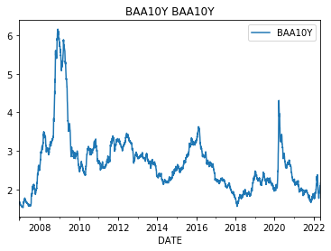

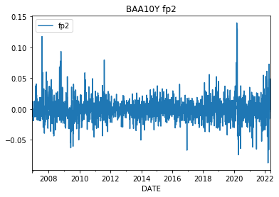

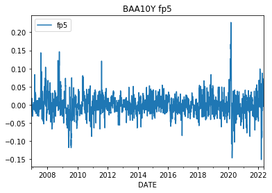

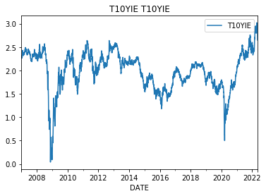

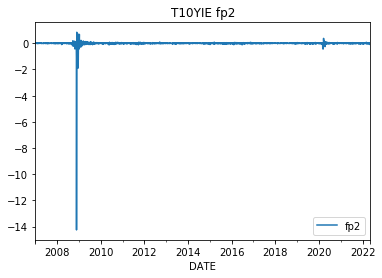

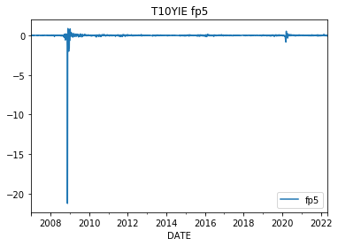

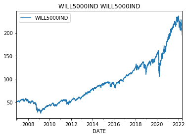

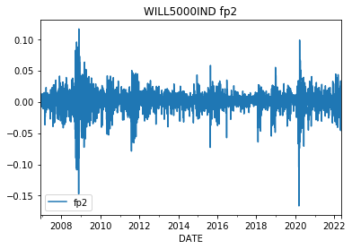

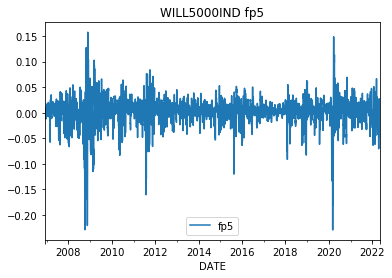

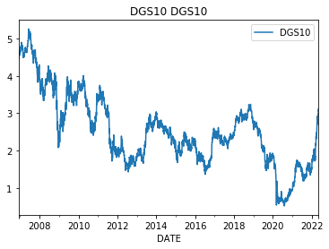

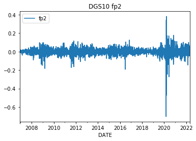

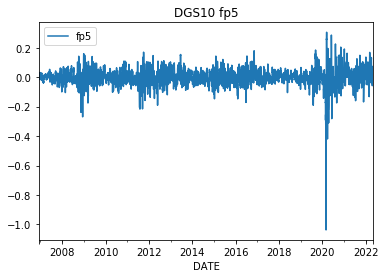

[6 more figures not shown]

```python
#
# Display plots of all the time series and their transforms.
#
# Outer loop is the series key
for v in dict_series:

    # inner loop is all data columns
    # only works if date is an index - not a column
    for u in dict_series[v]:

        if u != "DATE":
            dict_series[v].plot( x = "DATE", y = u)
            plt.title(v + " " + u)
            plt.show()
```

### $\color{green}{\text{2.3 - Exploratory Data Analysis}}$

We consider some aspects over this lengthy period:

- the linguistic patterns of FOMC statements in different regimes
- the federal funds target rate over this period. This rate is set within each FOMC statement and is viewed as an `output` of the FOMC process.
- the macroeconomic variables including economic growth, inflation and labor market conditions. These indicators are key `inputs` to the FOMC process.
- financial market variables are both `inputs` and responses to the FOMC process.

### Linguistic Patterns

As the chairperson and the members of the FOMC committee write and/or approve the text language, we expect textual variations due to the chairperson. The below table and chart shows the FOMC policy statement length (in words) by chairperson and time.

- Ben Bernanke was the Federal Reserve chairman from 2006 - 2014. (https://www.federalreservehistory.org/people/ben-s-bernanke)
- Janet Yellen was the Federal Reserve chairwoman from 2014 - 2018. (https://www.federalreservehistory.org/people/janet-l-yellen)
- Jerome Powell is the current Federal Reserve chairman from 2018 - present. (https://www.federalreservehistory.org/people/jerome-h-powell)

[figure not shown]

```python
a.sort_values(by=["year"] )[["length"]].style.set_table_styles(dfstyle)
```

| chairperson | length |
| --- | --- |
| Bernanke | 442.949153 |
| Yellen | 602.656250 |
| Powell | 407.942857 |

### Federal Funds Target Rates

During the study period, we see that the FOMC target for the federal funds rate varied significantly. Moreover, during the 2008 financial crisis, the FOMC changed its practice from setting a single rate to setting a target range with a lower and upper bound on the range. The key features of the rate setting over this period are:

- Rate reduced from 5-1/4 percent in 2007 to 0-1/4 percent target rate in 2009 as the 2008 Financial Crisis worsened.
- Lengthy period of near zero target rate from 2009 - 2016 as the FOMC tried to resuscitate a weak labor market and weak inflation.
- Steady rate increases from 2016-2020 as economic conditions and labor markets improved.
- Rate cuts from 2020-Jan 2022 to battle the economic effects of the Covid-19 pandemic.
- Rate increases from March 2022 to battle inflation.

[figure not shown]

### Macroeconomic Conditions

We examine the unemployment rate (U-3) `UNRATE` and the Labor Participation Rate `CIVRATE`, defined as the percentage of of people in the labor force as a percentage of the civilian noninstitutional population. Both statistics are reported monthly by the Bureau of Labor Statistics. The chart below shows their time series.

- `CIVRATE` shows a steady decline from 66-62% from 2007-2015 before regaining some ground in 2016-2020. The arrival of Covid-19 caused a massive decline in labor force participation to 60% in 2020. This phenomenon has been called the `Great Resignation`.
- `UNRATE` shows the traditional measure of unemployment. It increased significantly during the 2008 financial crisis and remained high even after financial markets recoved in 2010. However, the short term spike in unemployment during the Covid-19 pandemic showed that enormous economic cost of lockdowns and disruptions to businesses.

[figure not shown]

Concurrently, we see that real GDP growth below. Expressed in percentage form as the quarterly change in real GDP over a 12-month period, `GDPC1` shows a significant drop during both the 2008 Financial Crisis and the 2020 Covid-19 induced recession. The rebound in GDP is sharper for the 2020 recession because its cause is physical rather than financial.

[figure not shown]

### Financial Market Variables

We plot the previously mentioned 4 financial time series from the FRED database which represent interest rates, credit, inflation and equity markets.

- **BAA10Y**, Moody's Seasoned Baa Corporate Bond yield relative to yield on 10-year Treasury Constant Maturities.
- **T10YIE**, the breakeven inflation rate represents the expected inflation derived from 10-Year Treasury constant maturity securities minus the 10-Year Treasury Inflation-Indexed Constant Maturity index. It represents market expectations of average inflation over the next 10 years.
- **WILL5000IND**, the total returns of the Wilshire 5000 Stock Index, observed daily, including reinvested dividends. This is a broad measure of the entire US stock market.
- **DGS10**, the yield on 10-year Treasury Constant Maturities.

[figure not shown]

```python
plot_panel_financials()
```

## $\color{blue}{\text{3 - Topic Modeling of FOMC Statements}}$

- Preprocessing and Vectorization of Corpus
  - Stopwords - FOMC specifics
  - Bigrams, WordNet Lemmatizer
- N = 5 Topics Suffice using LDA.
  - Each Topic is associated with 1 period of QE
- Interpretation
  - High Frequency Words in each Topic
  - Word Clouds
  - Time Variation of Topic Weights

This section begins by preprocessing the FOMC statement corpus. Next, we train the LDA model and report the topics textually and graphically. Next, we report the Time Variation of the Topics and their interpretation. Lastly, we consider coherence as a topic evaluation measure for FOMC statements. In our discussion, we consider potentially useful business application of LDA topic modeling as an automated form of Fed-watching.

### $\color{green}{\text{ 3.1 - Pre-process and vectorize the documents}}$

The statements were downloaded and extracted in a previous step for consumption. There are 126 statements for use. We use `gensim`, `nltk` to preprocess the corpus.

```python
df_fomc_statements_raw.tail()
```

|  | statement_id | date | year | url | text | length | chairperson |
| --- | --- | --- | --- | --- | --- | --- | --- |
| 121 | 122 | 2021-11-03 | 2021 | https://www.federalreserve.gov/newsevents/pres... | The Federal Reserve is committed to using its ... | 614 | Powell |
| 122 | 123 | 2021-12-15 | 2021 | https://www.federalreserve.gov/newsevents/pres... | The Federal Reserve is committed to using its ... | 521 | Powell |
| 123 | 124 | 2022-01-26 | 2022 | https://www.federalreserve.gov/newsevents/pres... | Indicators of economic activity and employment... | 430 | Powell |
| 124 | 125 | 2022-03-16 | 2022 | https://www.federalreserve.gov/newsevents/pres... | Indicators of economic activity and employment... | 348 | Powell |
| 125 | 126 | 2022-05-04 | 2022 | https://www.federalreserve.gov/newsevents/pres... | Although overall economic activity edged down ... | 366 | Powell |

```python
ldocs = list(docs)
```

Following the approach suggested by [Radim Rehurek](https://radimrehurek.com/gensim/auto_examples/tutorials/run_lda.html#sphx-glr-auto-examples-tutorials-run-lda-py) in his LDA tutorial, our steps include:

- Tokenize (split the documents into tokens).
- Lemmatize the tokens.
- Compute bigrams.
- Compute a bag-of-words representation of the data.
- Convert the bag-of-words to Term Document - Inverse Document Frequency Weighting.

First we tokenize the text using a regular expression tokenizer from NLTK. We remove numeric tokens and tokens that are only a single character, as they don't tend to be useful, and the dataset contains a lot of them.

We also add FOMC specific stopwords as they don't appear to add value to the statements. These include the words chair, vice, voting, committee and FOMC. They also include the first and last names of all FOMC members from 2007-2022. These were identified manually on the Federal Reserve website.

We find bigrams in the documents. Bigrams are sets of two adjacent words. Using bigrams we can get phrases like "public_health" in our output (spaces are replaced with underscores); without bigrams we would only get "public" and "health".

Note that in the code below, we find bigrams and then add them to the original data, because we would like to keep the words "public" and "health" as well as the bigram "public_health".

We remove rare words and common words based on their *document frequency*. Below we remove words that appear in less than 5 documents. However, we keep words that appear in all documents like `inflation` because their frequency and associated bigram phrases can be helpful.

Finally, we transform the documents to a vectorized form. We simply compute the frequency of each word, including the bigrams.

Let's see how many tokens and documents we have to train on.

There are 754 tokens on 126 documents.

### $\color{green}{\text{3.2 - Training}}$

We are ready to train the LDA model.

#### Choosing the Number of Topics

How many topics should we use to train the model? Our financial markets knowledge gives us some guidance although in the end there are no clear answers.

- First, the Federal Reserve has to a dual mandate: managing inflation and promoting full employment consistent with a target level of inflation. Thus, each statement is expected to address *inflation* and the *labor market*.
- We know that a central bank is a lender of last resort. It needs to rescue the national economy from financial crisis. Thus, *financial crisis management* can be expected to be a relevant topic. In particular, we can expect
  - *quantitative easing*
  - *extraordinary lending facility* (e.g. swap lines, TALF) to be potential topics.
- The target Fed Funds rate is decided and announced at each FOMC meeting. Thus, *rate setting* ought to be a topic.
- Each statement also may provide forward guidance on the FOMC's trajectory of rate increases or crisis management measures. This is consistent with the Federal Reserve's desire to improve transparency after the 2008 Financial crisis.

Because the statements are brief, we do not expect numerous topics to appear in the documents. Parameter values in excess of 10 are likely to produce nonsensical results. In addition, other academic research on the FOMC minutes suggest an optimal topic number of 8, see [Jegadeesh and Wu (2013)](https://doi.org/10.2139/ssrn.2939937). We view FOMC minutes as an upper bound on the topic choice. Minutes are lengthier versions of the meeting discussions associated with each FOMC statement.

```python
model = LdaModel(
    corpus=trans_TFIDF,
    id2word=id2word,
    chunksize=chunksize,
    alpha='auto',
    eta='auto',
    num_topics=num_topics,
    random_state = SEED ,
    passes=passes,
    eval_every=eval_every
)
```

#### Extract Topic Ranking

The `gensim` framework is used to extract `U_Mass` topic coherence to rank the topic importance of each topic.

```python
df_merge.head()
```

|  | top_word | rank | topic_id | top_prob | coherence | Topic |
| --- | --- | --- | --- | --- | --- | --- |
| 0 | flow_credit | 1 | 2 | 0.008720 | -0.348400 | QE4 |
| 1 | purchase | 2 | 0 | 0.008475 | -0.402065 | QE3 |
| 2 | strong | 3 | 4 | 0.008923 | -1.190280 | QE-HALT |
| 3 | board | 4 | 1 | 0.009046 | -1.794918 | QE1 |
| 4 | coming_quarter | 5 | 3 | 0.006932 | -3.530968 | QE2 |

### $\color{green}{\text{3.3 - Analysis of Topics}}$

We analyze the LDA topics in several ways.

- Examine highest frequency words.
- Word Clouds
- Time Series of Topic Weights within the training corpus
- 2 dimensional PCA analysis of intertopic distance.

In this case, we will conclude that time series analysis provides the most useful insights. However, we consider each method in turn and check for insights.

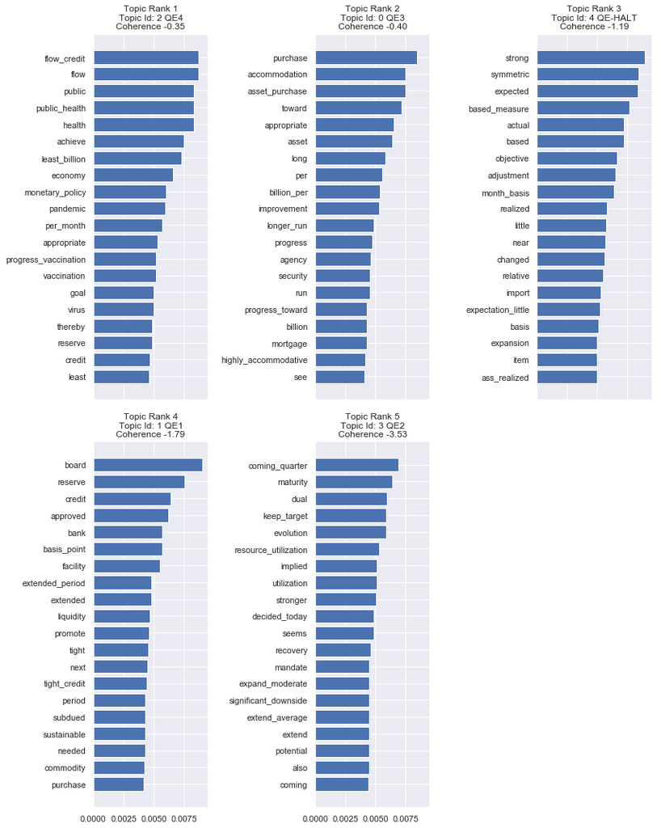

```python
plot_frequency_charts()
```

#### Findings

What have we learned from the above frequency charts for each topic?

- Topic (`QE4`) is associated with the economic crisis induced by the Covid pandemic. This is evident from the use of the high frequency words: `public`, `public_health` and `pandemic`, `virus`, `vaccination`.
- Topic (`QE3`) is associated with quantitative easing and asset purchases. So we can confidently associated Topic 0 with Quantitative easing. But since the FOMC has initiated multiple rounds of QE, we don't know which one the FOMC supports. We will resolve this puzzle in the later section.
- Topics `QE-HALT`, `QE1`, `QE2` are ambiguous because the words don't explain the topic. Moreover, the highest frequency words are non-specific. `strong`, `symmetric`, `board`, `reserve`, `coming_quarter`, `maturity` are the top frequency **generic** words.

We need to look at other methods to extract the topic interpretations.

#### Plotting Word Clouds

Word Clouds are even less useful than frequency charts, but they allow overlooked words to be detected. In this case, they are uninformative.

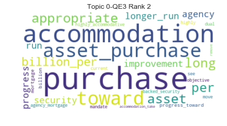

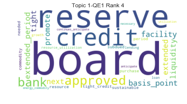

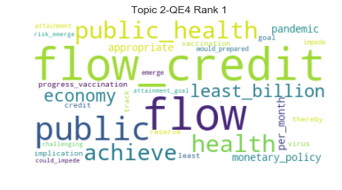

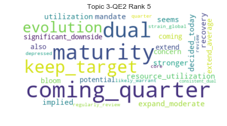

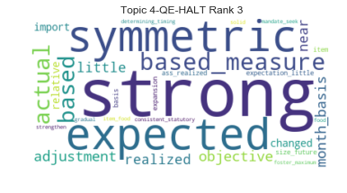

```python
plot_wordclouds()
```

#### Time Series

Finally, we consider the time evolution of each topic within the training corpus.

Each document is assigned a set of topics and weight. The assigned topic identifiers follow the internal numbering convention of the model. After obtaining the set of all topic weights for all documents, we will construct a dataframe $X$ of dimension $D \times T$ where $X(d,t)$ is the weight of document $d$ in topic $t$. However, when $d$ has no association with topic $t$, $X(d,t) = 0$.

We transform the skinny table into a $D \times T$ dataframe using `pivot_table` functionality in pandas.

For ease of reading, we rename the columns from the topic i to the Quantitative easing topic descriptions.

```python
topic_weights_hist.head()
```

| date | QE3 | QE1 | QE4 | QE2 | QE-HALT |
| --- | --- | --- | --- | --- | --- |
| 2007-01-31 | 0.0 | 0.0 | 0.0 | 0.970152 | 0.0 |
| 2007-03-21 | 0.0 | 0.0 | 0.0 | 0.969345 | 0.0 |
| 2007-05-09 | 0.0 | 0.0 | 0.0 | 0.970305 | 0.0 |
| 2007-06-28 | 0.0 | 0.0 | 0.0 | 0.971399 | 0.0 |
| 2007-08-07 | 0.0 | 0.0 | 0.0 | 0.973179 | 0.0 |

#### All Topics At Once

Before we examine each topic's history individually, we display them jointly. A few observations are in order.

- The topics display sharp boundary behavior. Topics go in and out of use without significant transition. This suggests that the LDA model is effective in detecting different subjects.
- The topic transitions occur concurrently. When one topic fades in importance, another topic takes over in importance. This is consistent with the topic languages shiftly due to policy and the boiler plate language.
- The sum of the topic weights do not exceed 100%.
- Topic 0 (QE3) is clearly associated with quantitative easing because the highest frequency words: `purchase`, `asset_purchase`, `accomodation`.

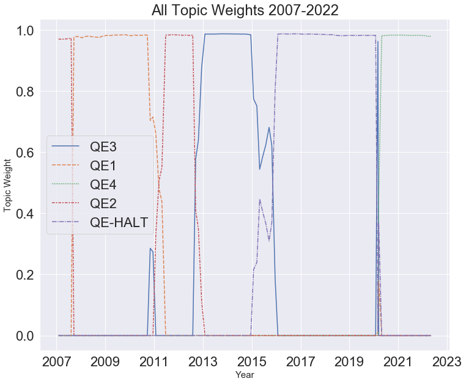

```python
plot_all_topic_weights()
```

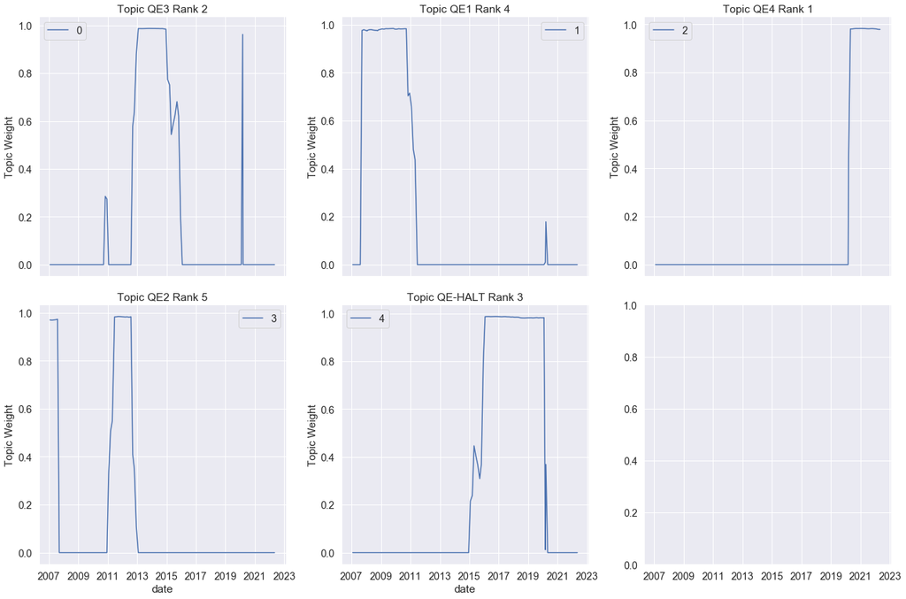

```python
show_panel_topic_weights()
```

#### Mapping Topics to Quantitative Easing Regimes

Quantitative easing (QE) is the central bank strategy to support financial markets by buying assets using the central bank's unlimited balance sheet. Wikipedia observes:

> Quantitative easing is an unconventional form of monetary policy, which is usually used when inflation is very low or negative, and when standard monetary policy instruments have become [ineffective.](https://en.wikipedia.org/wiki/Quantitative_easing#United_States)

This approach was necessary in the 2007-2022 period because interest rates were so low. When the Central bank hits the zero lower bound on interest rates, the bank's ability to encourage credit and investment is limited because interest rates cannot be lowered further.

Instead, the bank has embarked on four successive waves of asset purchases called QE1, QE2, QE3 and QE4.

See [Quantitative Easing](https://en.wikipedia.org/wiki/Quantitative_easing) for more details of the monetary policy and its implementation by major central banks. We note that there is not universal agreement on the chronology and even naming of the waves of quantitative easing. We follow the chronology and naming in Wikipedia but note that The Balance give different dates and even consider QE4 to be an extension of QE3.

[figure not shown]

The table below summarizes the QE program dates when the Federal Reserve started and ended buying of assets and compares them to the dates when each topic has significant non-zero weight (typically more than 10%).

[figure not shown]

While the high frequency words of each topic are uninformative in explaining the underlying cause of the topics, the time evolution of topic weights gives us more precise, hidden patterns.

- The date alignment of the start of QE4 and QE3 are very close to the actual QE policy changes.
- The end of the QE is sometimes left clearly identified by the LDA algorithm.
- The halt of QE1 is not well identified. But the entire 2007-2008 period was an extended series of increasingly severe financial market disruptions.
- The identification of QE2 is quite close (within 3 months).

### Interactive Visualization Of Topics

We also evaluate the LDA model interactively using the `pyLDAvis` package below.

The `pyLDAvis` visualization produces an intertopic distance map using MDS (multidimensionsal scaling) to produce a principal components plot of PCA dimensions 1 and 2 (labelled `PC1`, `PC2`).

```python
import warnings
warnings.filterwarnings('ignore')

import pyLDAvis
import pyLDAvis.gensim_models as gensimvis

pyLDAvis.enable_notebook()
pyLDAvis.gensim_models.prepare( model, trans_TFIDF , dictionary, sort_topics = False)
```

[interactive chart not shown]

From the `pyLDAvis` visualization, we conclude that

- the topics are well separated. A lack of overlapping circles, each of which represents a topic, tells us that the model is doing a good job in identifying distinct topics.
- In this case, the only overlaps occur between `QE1` (the circle labeled 2) and `QE2` (the circle labeled 4).

The linkage between QE and topics is not visible in this analysis.

Moreover, the term bar chart is nearly equivalent in content to the earlier frequency bar charts.

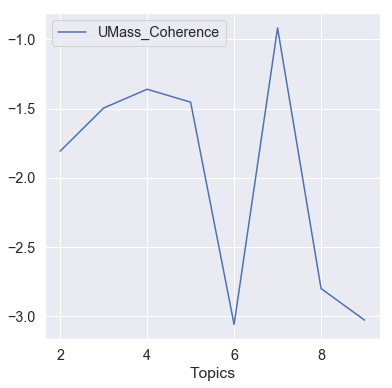

```python
df_mod_results = pd.DataFrame( mod_results , columns = ['Topics', 'UMass_Coherence'] )
df_mod_results.plot(x="Topics", y = "UMass_Coherence")
```

### $\color{green}{\text{3.4 - Discussion}}$

When new policies about Quantitative easing are introduced, the text style of the FOMC statements appears to change. These changes appear to be detectable by LDA. This is consistent with the central bankers wishing to signal a change of monetary policy through a change in text style.

Does the FOMC make the textual changes intentionally? We believe they are because the reactions of market participants can be moved by single adjective changes between consecutive statements. Fedwatching is a highly nuanced study of subtle changes in language.

Why is LDA less accurate in detecting the end of QE?

- curtailment of asset purchases is data dependent
- New QE policies requires more upfront explanation of scope, size and rationale
- Ending QE occurs when economic conditions are more benign.

Besides the FOMC statements, a human analyst would examine FOMC minutes, transcripts, Beige Book, Blue Book , speeches and market commentary from other experts.  
These works would shed insight beyond what an LDA model can provide. However, LDA provides a concrete measurement of what an analyst may struggle to express in words, his subjective opinion of future FOMC decision making.

## $\color{blue}{\text{4 - Sentiment Analysis of FOMC Statements}}$

- Preprocessing and Transformation of Corpus
  - Tokenization
  - Stopwords - common English language
  - Lemmatization
- Application of 4 Sentiment Analysis libraries
  - NLTK Sentiment Intensity Analyzer
  - TextBlob
  - Flair
  - PySentiment implementation of Loughran-McDonald dictionary
- Evaluation
  - Visualizations of sentiment scores as time series
  - Manual assessment of selected FOMC statements
- Regression of Sentiment Scores and Financial Variables
  - Macroeconomic values as predictor of sentiment score
  - Financial variables as respones of sentiment score

Given the importance and timely release of the FOMC statements, we attempt to identify a statistically significant relationship between the FOMC sentiment score and the macroeconomic conditions or financial markets variables over a multiple-day horizon during the years 2007-2022.

We generate an overall sentiment score for each statement based on 4 different Python libraries. For additional comparison purposes, we generate the score on the raw text and a transformed version of each statement.

In order to generate valid linear regression models, we calculate the difference in the sentiment score compared to the previous sentiment score, a lag of one. We also calculate a corresponding difference for the macroeconomic values and financial market variables to construct univariate linear regression models. In the end, we are unable to find a statistical significance between the change in sentiment score and the change in economic variables given a multi-day window as the markets are efficient in incorporating the impact of FOMC statements.

This section begins by preprocessing and transforming the FOMC statement corpus. Next, we apply the 4 different Sentiment Analysis libraries to determine appropriateness of each algorithm. Next, we construct the linear regression models based on the change in sentiment score and financial variables. Lastly, after initial consideration of several variables, we focus our attention on the Wilshire variable across 25 different multi-day timeframes, but none of the linear regression models prove significant.

### $\color{green}{\text{ 4.1 - Data Transformation}}$

For the sentiment analysis extraction, we perform data transformations to ensure proper uniformity of the words along with common language transformations to prepare the data for the sentiment analysis algorithms.

- Lowercase all characters
- Tokenize character strings to remove punctuation
- Remove stopwords (common words of the English language)
- Lemmatize the text tokens to ensure analysis on the lemma or dictionary term

The list of words in the `text_token` column are joined to form a single character string entry.

### $\color{green}{\text{ 4.2 - Sentiment Analysis Generation}}$

We apply the sentiment analysis to both the raw text of the FOMC statements and the transformed text tokens to allow for comparison between the two formats.

We attempt four approaches to Sentiment Analysis available in Python to generate the sentiment score for each statement.

- NLTK's Sentiment Intensity Analyzer (https://www.nltk.org/howto/sentiment.html)
- TextBlob (https://textblob.readthedocs.io/en/dev/)
- Flair (https://github.com/flairNLP/flair)
- PySentiment (https://pypi.org/project/pysentiment2)

#### NTLK Sentiment Intensity Analyzer

From `NLTK`, the `SentimentIntensityAnalyzer` produces four scores for each text: negative, neutral, positive, and compound. The `SentimentIntensityAnalyzer` relies on the VADER, Valence Aware Dictionary and sEntiment Reasoner. The VADER approach is a lexicon and rule-based sentiment analysis tool primarly developed for sentiment in social media. VADER contains a list of words with a semantic orientation as positive or negative. We use the compound score, as the metric represents a sum of all the lexicon ratings and then normalized between -1 (most negative) and 1 (most positive).

Now, we perform the above steps on the transformed `text_token` column.

The resulting sentiment scores for the raw text and transformed text are quite similar, showing the `SentimentIntensityAnalyzer` works well on both sets of text for this corpus.

#### TextBlob

The `TextBlob` module follows the `Pattern` module approach to sentiment scoring. The `TextBlob` polarity score evaluates a text to -1 (most negative) to +1 (most positive). (https://textblob.readthedocs.io/en/dev/quickstart.html#sentiment-analysis)

We apply the sentiment analysis to the raw text and the text tokens.

Again, we see for the evaluation of the raw text and the transformed text, the `TextBlob` analyzer performs similarly on both sets of input.

#### Flair

The module `Flair` builds directly on PyTorch, a deep learning framework, to perform sentiment analysis. Again, we perform the sentiment analysis on the raw text and the transformed text tokens.

The `Flair` results only return an overall assessment of the text as either positive or negative along with a confidence score. As these results do not capture the sentiment on a specific scale, the `Flair` module will not be considered for the final evaluation.

#### PySentiment

The module `PySentiment` provides two dictionaries in the library, the Harvard IV-4 and Loughran and McDonald Financial Sentiment Dictionaries, which are sentiment dictionaries for general and financial sentiment analysis. We use the the Loughran and McDonald Financial Sentiment Dictionary of the `PySentiment` module to determine the polarity of each FOMC statement. According to the `PySentiment` documentation, the polarity is calculated in the same way of the Lydia system. The formula for polarity is:

$Polarity = \frac{(postive\_words\ -\ negative\_words)}{(positive\_words\ +\ negative\_words)}$

https://sraf.nd.edu; https://pypi.org/project/pysentiment2/

The use of the Loughran and McDonald Financial Sentiment Dictionary shows promising results in the sentiment analysis of the FOMC statements. Given the financial nature of the FOMC statements, this sentiment outcomes based on the financial sentiment dictionary was anticipated.

#### Visualizations

Next we visualize the sentiment analysis results as a time series in order to evaluate the ebb and flow of the sentiment from 2007 to 2022.

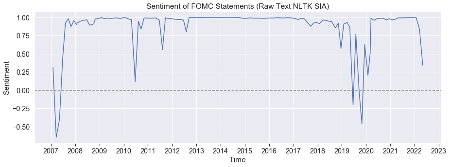

```python
plot_sentiment_nltk_sia()
```

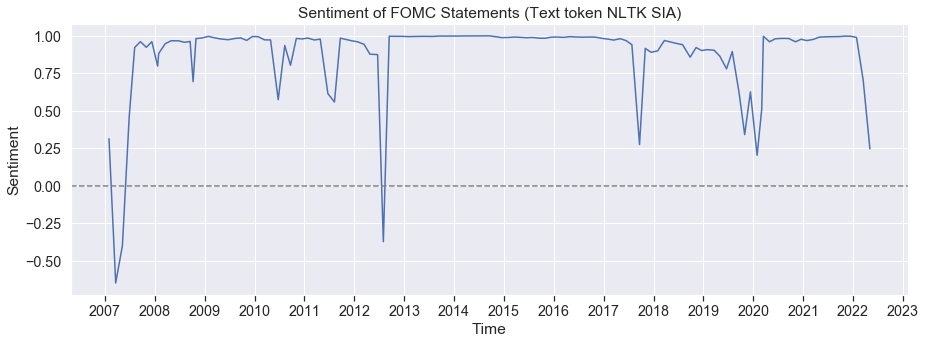

```python
plot_nltk_sia_tt()
```

We see the `NLTK` SentimentIntensityAnalyzer provides an overall sentiment score near the extremes of the evaluation range -1 to 1.

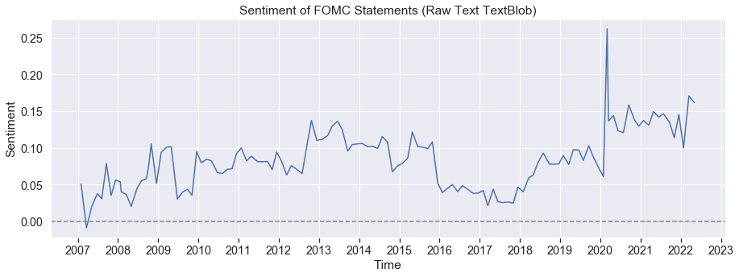

```python
plot_textblob_rawtext()
```

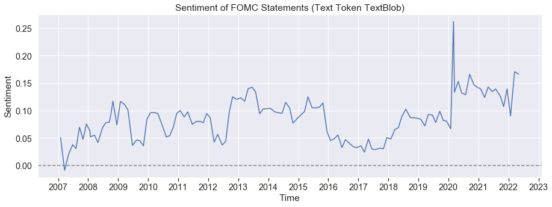

```python
plot_textblob_tt()
```

The `TextBlob` sentiment scores indicate near always positive results which seems incongruous with the economic hardships in 2008 and the beginning of 2020.

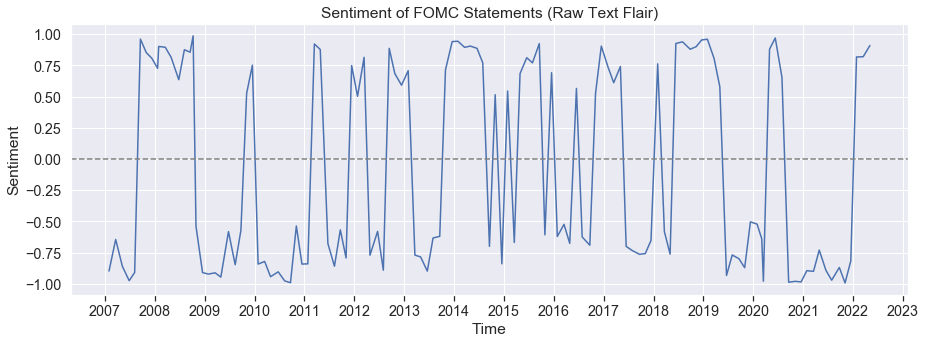

```python
plot_flair_raw()
```

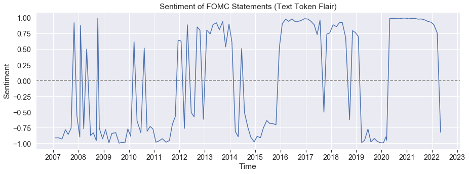

```python
plot_flair_tt()
```

The `Flair` module produces sentiment analysis does not make sense.

- During the 2008 recession, Flair shows wild variations in sentiment instead of a decline.
- During the 2020 recession, Flair shows a positive sentiment during Covid.

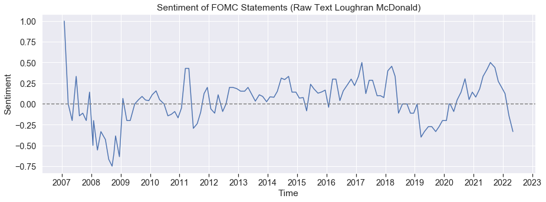

```python
plot_lm_raw()
```

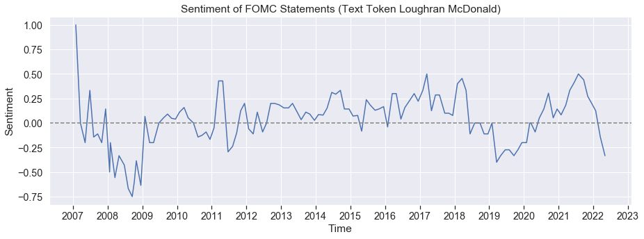

```python
plot_lm_tt()
```

The `PySentiment` module and use of the Loughran and McDonald Financial Sentiment Dictionary generates a sentiment plot that does indicate a relationship to the economic hardships of 2008 and 2020, more inline with the expectations given the historical context.

### $\color{green}{\text{ 4.3 - Specifying the Regressions}}$

We implement the dataframes containing the variables to be regressed below.

- The sentiment indicator is put into a dataframe called `df_sentiment`
- The market variables to be regressed are aligned by date.

We use the pandas `merge_asof` to do approximate date matching correctly.

#### Approach

Let the sentiment variable be denoted as $Z$.

For macroeconomic variables $Y$: we estimate the model $Z = f(Y)$.

- We explain the sentiment variable in terms of macroeconomic variable.

For financial market variable $X$: we estimate the model $X = g(Z)$.

- We explain the financial variable in terms of sentiment variable.

Date Alignment for macroeconomic model fit: for each FOMC date $f(i)$ and the prior FOMC meeting date $f(i-1)$ find the macroeconomic variable for the same month and year.

We estimate a model based on the change in sentiment $Z[f(i)] - Z[f(i-1)]$

We compare the sentiment variable to the prior change in macroeconomic `bd1` (backward difference of 1 lag) or `bp12` (backward proportional change over 12 months).

### Macroeconomic Variables

#### CIVPART

The linear regression model explains the FOMC statement sentiment score in terms of the Labor Force Participation Rate. For this financial variable, we use a backward difference of 1 lag - `bd1`.

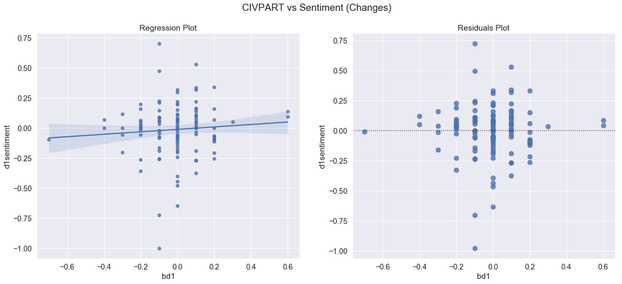

```python
plot_civpart_bd1()
```

```python
print(mod_fit_CIVPART_bd1.summary())
```

```
                            OLS Regression Results
==============================================================================
Dep. Variable:            d1sentiment   R-squared:                       0.006
Model:                            OLS   Adj. R-squared:                 -0.002
Method:                 Least Squares   F-statistic:                    0.7507
Date:                Thu, 19 May 2022   Prob (F-statistic):              0.388
Time:                        21:35:08   Log-Likelihood:                 13.760
No. Observations:                 125   AIC:                            -23.52
Df Residuals:                     123   BIC:                            -17.86
Df Model:                           1
Covariance Type:            nonrobust
==============================================================================
                 coef    std err          t      P>|t|      [0.025      0.975]
------------------------------------------------------------------------------
const         -0.0095      0.020     -0.486      0.628      -0.048       0.029
bd1            0.1017      0.117      0.866      0.388      -0.131       0.334
==============================================================================
Omnibus:                       31.986   Durbin-Watson:                   2.329
Prob(Omnibus):                  0.000   Jarque-Bera (JB):              109.089
Skew:                          -0.845   Prob(JB):                     2.05e-24
Kurtosis:                       7.253   Cond. No.                         6.01
==============================================================================

Notes:
[1] Standard Errors assume that the covariance matrix of the errors is correctly specified.
```